# Estudiantes en situación de desplazamiento en Santander

Marlon Barajas Acelas y Luis Chaparro Castaño

2023-12-06

# Introducion

El desplazamiento forzado en Colombia, a causa del conflicto armado, ha afectado a más de seis millones de personas en los últimos treinta años. A partir de esto surgen cuestiones sobre ¿cuáles causas de desplazamiento son las más comunes?, ¿qué tipo de educación reciben las personas en esta situación?, todo esto según su ubicación actual, edad, género u otros aspectos característicos de cada individuo. Con la intención de conocer esta información y dar a entender de una manera general y más sencilla la situación de los estudiantes desplazados en el departamento de Santander, se planean usar los datos proporcionados por el estado colombiano para el año 2022.

# Paquetes de R requeridos

- library(readxl) #lectura de archivos de excel
- library(tidyverse) #manipulación y análisis de datos
- library(skimr) #resúmenes estadísticos para marcos de datos
- library(DT) #presentación de tablas y conjuntos de datos
- library(knitr) #generación dinámica de reportes
- library(kableExtra) #manipulación y creación de tablas
- library(dplyr) #manipulación y creación de tablas

# Preparación de los datos

Los datos usados para el estudio son los proporcionados por el estado colombiano en [Estudiantes en situación de desplazamiento en Santander](https://www.datos.gov.co/Educaci-n/ESTUDIANTES-EN-SITUACI-N-DE-DESPLAZAMIENTO-EN-SANT/wemp-b8gd) cuya última actualización a la fecha es del 30 de septiembre de 2022.

|  | d_ano | d_muni | d_nombmuni | d_provincia | d_nomsec | d_nomzon | dane_ant | d_nombinst | d_sede | d_nombsede | d_nomjor | d_grado | d_edad | d_genero | d_hombres | d_mujeres | d_tipo | metodo | sector | edad | etnia | discapa |
| --- | --- | --- | --- | --- | --- | --- | --- | --- | --- | --- | --- | --- | --- | --- | --- | --- | --- | --- | --- | --- | --- | --- |
| 1 | 2022 | 13 | AGUADA | VÉLEZ | OFICIAL | URBANA | 168013000016 | COLEGIO INTEGRADO ROEL Y VELASCO | 168013000016A | COLEGIO INTEGRADO ROEL Y VELASCO | MAÑANA | 1 | 7 | F | 0 | 1 | DESPLAZAMIENTO FORZADO | EDUCACION TRADICIONA | 1 | 7 | NINGUN GRUPO ETNICO | NO TIENE DISCAPACIDAD |
| 2 | 2022 | 13 | AGUADA | VÉLEZ | OFICIAL | URBANA | 168013000016 | COLEGIO INTEGRADO ROEL Y VELASCO | 168013000016A | COLEGIO INTEGRADO ROEL Y VELASCO | MAÑANA | 7 | 13 | F | 0 | 1 | EN SITUACION DE DESPLAZAMIENTO | EDUCACION TRADICIONA | 1 | 13 | NINGUN GRUPO ETNICO | NO TIENE DISCAPACIDAD |
| 3 | 2022 | 20 | ALBANIA | VÉLEZ | OFICIAL | URBANA | 168020000374 | COLEGIO DEPARTAMENTAL INTEGRADO SAGRADO CORAZON DE | 168020000374A | COLEGIO DEPARTAMENTAL INTEGRADO SAGRADO CORAZON DE | MAÑANA | 10 | 16 | F | 0 | 1 | EN SITUACION DE DESPLAZAMIENTO | EDUCACION TRADICIONA | 1 | 16 | NINGUN GRUPO ETNICO | NO TIENE DISCAPACIDAD |
| 4 | 2022 | 20 | ALBANIA | VÉLEZ | OFICIAL | URBANA | 168020000611 | COLEGIO DEPARTAMENTAL INTEGRADO SAGRADO CORAZON DE | 168020000374B | ESCUELA URBANA ULPIANO MUÑOZ | MAÑANA | 4 | 9 | M | 1 | 0 | VICTIMAS DE MINAS | EDUCACION TRADICIONA | 1 | 9 | NINGUN GRUPO ETNICO | NO TIENE DISCAPACIDAD |
| 5 | 2022 | 20 | ALBANIA | VÉLEZ | OFICIAL | RURAL | 268020000158 | COLEGIO DEPARTAMENTAL INTEGRADO SAGRADO CORAZON DE | 168020000374C | ESCUELA RURAL CANOAS | MAÑANA | 3 | 9 | M | 1 | 0 | EN SITUACION DE DESPLAZAMIENTO | ESCUELA NUEVA | 1 | 9 | NINGUN GRUPO ETNICO | NO TIENE DISCAPACIDAD |
| 6 | 2022 | 20 | ALBANIA | VÉLEZ | OFICIAL | RURAL | 268020000051 | COLEGIO DEPARTAMENTAL INTEGRADO SAGRADO CORAZON DE | 168020000374D | ESCUELA RURAL CANUTILLO | MAÑANA | 3 | 11 | M | 1 | 0 | HIJOS DE ADULTOS DESMOVILIZADO | ESCUELA NUEVA | 1 | 11 | NINGUN GRUPO ETNICO | NO TIENE DISCAPACIDAD |

# Variables más relevantes en los datos

| Variable | Descripcion |
| --- | --- |
| d_ano | Año del registro |
| d_muni | ID del municipio en el que se encuentra |
| d_nombmuni | Nombre del municipio en el que se encuentra |
| d_provincia | Nombre de la provincia en la que está ubicado |
| d_nomsec | Tipo de sector en el que se encuentra |
| d_nomzon | Tipo de zona en la que se encuentra |
| dane_ant | Código de ubicación geográfica de la institución |
| d_nombinst | Nombre de la institución en la cual está estudiando |
| d_sede | ID de la sede en la que se encuentra |
| d_nombsede | Nombre de la sede en la que está |
| d_nomjor | Jornada a la que asiste el estudiante |
| d_grado | Grado que cursa |
| d_edad | Edad del estudiante |
| d_genero | Género en formato de tipo caracter |
| d_hombres | Género en formato binario con 1 para masculino y 0 para femenino |
| d_mujeres | Género en formato binario con 0 para masculino y 1 para femenino |
| d_tipo | Razón o tipo de desplazamiento |
| metodo | Método por el cuál se brinda la educación |
| sector | Sector al que pertenece |
| etnia | Etnia a la que pertenece el estudiante |
| discapa | Discapacidad presente en el estudiante |

# Limpieza de datos

La limpieza se hace con la intención de eliminar columnas repetidas o innecesarias, como por ejemplo para la edad del estudiante se presentan dos columnas distintas (d_edad y edad), o en el caso del género tres columnas con valores equivalentes (d_genero, d_hombres, d_mujeres). Además de esto se modificaron los valores de la variable “d_sede” para eliminar la repetición del código geográfico de la institución. Finalmente se renombraron las variables, para facilitar la lectura de los datos al público y se removió la variable d_ano puesto que todos los registros corresponden en su totalidad al actual año 2022.

|  | ID_Municipio | NombreMunicipio | Provincia | NombreSector | Zona | CódigoGeográfico | NombreInstitucion | Sede | NombreSede | Jornada | Grado | Género | TipoDeDesplazamiento | MetodoEducación | Sector | Edad | Etnia | Discapacidad |
| --- | --- | --- | --- | --- | --- | --- | --- | --- | --- | --- | --- | --- | --- | --- | --- | --- | --- | --- |
| 1 | 13 | AGUADA | VÉLEZ | OFICIAL | URBANA | 168013000016 | COLEGIO INTEGRADO ROEL Y VELASCO | A | COLEGIO INTEGRADO ROEL Y VELASCO | MAÑANA | 1 | 0 | DESPLAZAMIENTO FORZADO | EDUCACION TRADICIONA | 1 | 7 | NINGUN GRUPO ETNICO | NO TIENE DISCAPACIDAD |
| 2 | 13 | AGUADA | VÉLEZ | OFICIAL | URBANA | 168013000016 | COLEGIO INTEGRADO ROEL Y VELASCO | A | COLEGIO INTEGRADO ROEL Y VELASCO | MAÑANA | 7 | 0 | EN SITUACION DE DESPLAZAMIENTO | EDUCACION TRADICIONA | 1 | 13 | NINGUN GRUPO ETNICO | NO TIENE DISCAPACIDAD |
| 3 | 20 | ALBANIA | VÉLEZ | OFICIAL | URBANA | 168020000374 | COLEGIO DEPARTAMENTAL INTEGRADO SAGRADO CORAZON DE | A | COLEGIO DEPARTAMENTAL INTEGRADO SAGRADO CORAZON DE | MAÑANA | 10 | 0 | EN SITUACION DE DESPLAZAMIENTO | EDUCACION TRADICIONA | 1 | 16 | NINGUN GRUPO ETNICO | NO TIENE DISCAPACIDAD |
| 4 | 20 | ALBANIA | VÉLEZ | OFICIAL | URBANA | 168020000611 | COLEGIO DEPARTAMENTAL INTEGRADO SAGRADO CORAZON DE | B | ESCUELA URBANA ULPIANO MUÑOZ | MAÑANA | 4 | 1 | VICTIMAS DE MINAS | EDUCACION TRADICIONA | 1 | 9 | NINGUN GRUPO ETNICO | NO TIENE DISCAPACIDAD |
| 5 | 20 | ALBANIA | VÉLEZ | OFICIAL | RURAL | 268020000158 | COLEGIO DEPARTAMENTAL INTEGRADO SAGRADO CORAZON DE | C | ESCUELA RURAL CANOAS | MAÑANA | 3 | 1 | EN SITUACION DE DESPLAZAMIENTO | ESCUELA NUEVA | 1 | 9 | NINGUN GRUPO ETNICO | NO TIENE DISCAPACIDAD |
| 6 | 20 | ALBANIA | VÉLEZ | OFICIAL | RURAL | 268020000051 | COLEGIO DEPARTAMENTAL INTEGRADO SAGRADO CORAZON DE | D | ESCUELA RURAL CANUTILLO | MAÑANA | 3 | 1 | HIJOS DE ADULTOS DESMOVILIZADO | ESCUELA NUEVA | 1 | 11 | NINGUN GRUPO ETNICO | NO TIENE DISCAPACIDAD |

# Análisis exploratorio de datos

A continuación se muestra un resúmen estadístico de las variables pertinentes para esta acción.

```
##    Min. 1st Qu.  Median    Mean 3rd Qu.    Max.
##    3.00   10.00   13.00   13.12   16.00   63.00
```

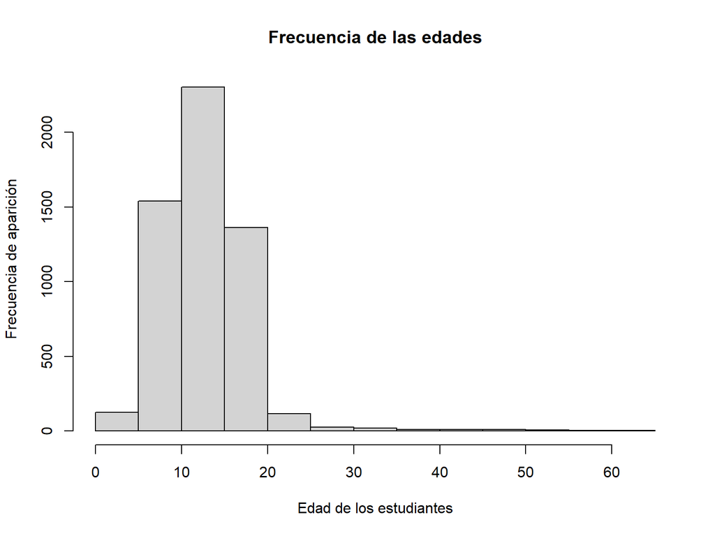

# outlayer?

En un principio se podría pensar que la edad máxima presentada en esta variable corresponde a un outlayer, puesto que el número se aleja bastante de las demás medidas. Con la intención de estudiar esto se puede relacionar la edad con el grado.

```
##    Min. 1st Qu.  Median    Mean 3rd Qu.    Max.
##   0.000   4.000   7.000   8.248  10.000  26.000
```

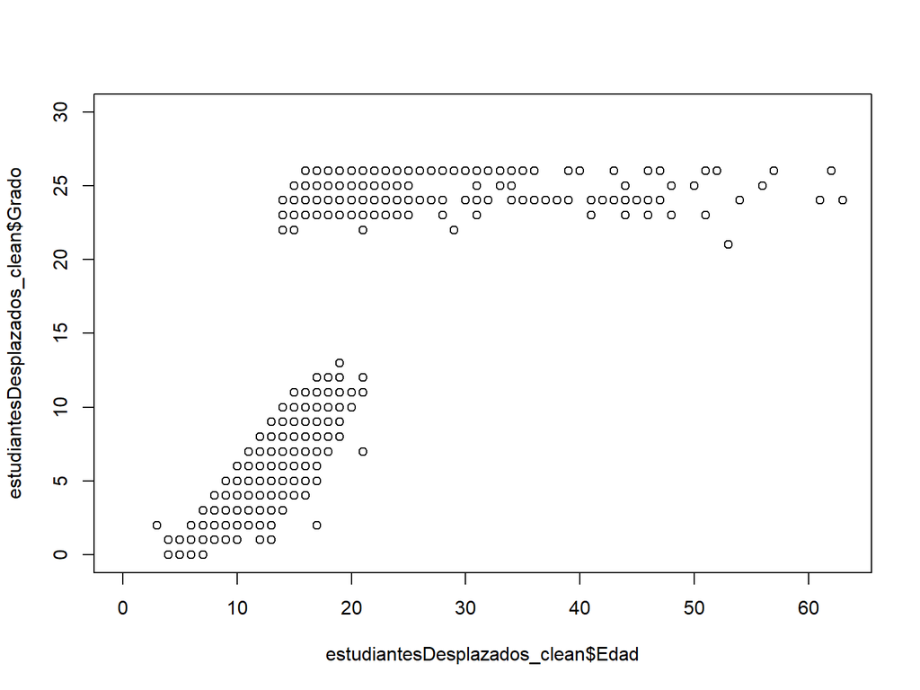

# Conclusiones

# Bibliografía

- @_2022_estudiantes
- @_2015_una
- @_desplazamiento